# Day 18 - Remote Servers

Spring 2023

[Dr. Jared Joseph](https://jnjoseph.com/)

Smith College

## Overview

### Timeline

- What is “Remote”
- Getting on Remote
- Working on Remote

### Goal

Learn what the basics of remote computing.

# What is “Remote”

## Local vs. Remote

### Local

[figure not shown]

### Remote

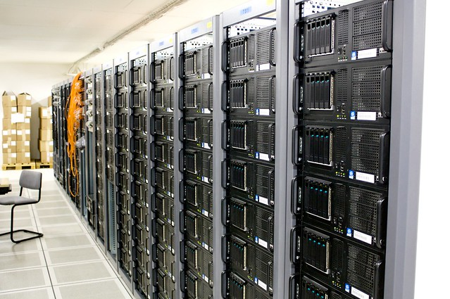

## Why Use Remote Compute

Let’s compare an average laptop with the Smith R Studio Server:

### Local

- ~8 Cores
- ~16 Threads
- ~8GB RAM
- ~500GB Storage

### Smith R Studio Server

- 48 Cores
- 96 Threads
- 64GB RAM
- 6.6TB Storage

Servers are just on a whole *different level* than personal machines

## Considerations with Remote

While working on a remote server can be a huge boon to large tasks, it is not a simple endeavor

Aside from having to exist, using a server adds some friction to the data science workflow

However, sometimes you just need more compute

### Limitations

- Server needs to exist ($$$)
- You need access and permissions
- Often need others to do tasks for you
- Sometimes offline/broken
- Need to be on the same network
- Need to make your code work on any machine
- Need to work in a shared environment

## Responsibilities of a Shared Resource

Working on a server comes with some responsibilities.

There are only so many resources; the more you take the less other have

If you are too greedy, you can crash the server for everyone–*killing other people’s jobs*

### How to not be a Jerk

- Check what is running already and how much of the server is free
- Don’t use too many cores
- Don’t use too much RAM
- Be NICE with your jobs (more later)
- Keep your user folder clean; delete old files

## Smith Servers

The college actually has *several* servers which you may not know about

Each servers a specific role, and you need permission to use any of them

I’ve registered you all for the R Studio server for this class

### Smith Servers

- R Studio
- R Studio 2
- General Linux
- Faculty Linux
- Jupyter
- Gitlab
- More?

# Getting on Remote

## A Primer on the R Studio Server

Smith College hosts an R Studio server students and faculty can use

You need an account to do so (I’ve made one for all of you)

You can access it by going to `rstudio.smith.edu` in your browser

[figure not shown]

## Login with Password

We don’t want to use the GUI (most servers won’t have one)

We use `ssh` (secure shell) to create an encrypted connection from our machine to the server

We can log in to the server on the command line using your Smith credentials, **you must be on the same network**

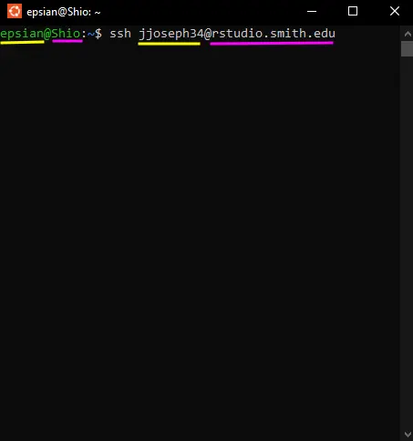

## Login with SSH

We can make things easier on ourselves by using the SSH key we created at the start of the class

Remember, SSH keys are identifiers for your computer, so can be like an alternative password identifying *your machine*

Just make sure you keep your keys safe!

Copy SSH Key

```
ssh-copy-id jjoseph34@rstudio.smith.edu
```

Create Shortcut (./.ssh/config)

```
Host srs
    HostName rstudio.smith.edu
    User jjoseph34
```

# Working on Remote

## Being a User

It is important to recognize on a remote sever, you are a *user*

This means you have limited access to files, what code you can run, and what you can download and install

Often, this means you will need the server admins to do some tasks for you, such as installing new software or creating shared directories

## Understanding the Machine

Most of your regular commands will work on a server (ls, cd, etc.)

Some become more important however, such as `top` or `htop`

These will help you know what is currently running on the server and how many resources are free

### Useful Commands

**`htop`**

See the current jobs running on the server and how many resources they are using

**`htop -u <YOUR NAME>`**

You can specify your user id to limit it to just your processes

**`lshw -short`**

This lets you know what hardware the machine is running

## Moving Files to/from Remote

We can use a program called `sftp` to move files between local and remote

It works similarly to `ssh` in that it creates a connection between the computers

However, it allows you to navigate both computers at the same time for the purpose of transferring files

### Useful `sftp` Commands

**`ls/lls`**

Lists files on remote/local

**`cd/lcd`**

Change directory on remote/local

**`get`**

Move files from remote to local

**`put`**

Move files from local to remote

## Running Code

You can run code normally on a remote server

However, given the shared nature, you can also be NICE

NICE sets a priority to jobs, such that you can rank how important a specific command is

### Being NICE

```
nice -n <NUM> <COMMAND>
```

Lower values == More Critical

## Remote Workflow

A common workflow for using remote servers would be as follows:

1. Code your project on local
2. Push to GitHub
3. Clone to remote
4. Copy data to remote
5. Run code on remote
6. Retrieve results

## A Note about GitHub

Remember, SSH keys are identifies for specific machines

Because working on a remote server *is a different machine* you will need to set up a new SSH key

You will then need to add this SSH key to your GitHub account

Otherwise, you won’t be able to push or pull anything

# Code-Along

## For Next Time

### Topic

Recap & Mid-Semester Review

### To-Do

- Complete Worksheet

SDS 270: Advanced Programming for Data Science